# Analysis roadmap

```python
import numpy as np
import pandas as pd
from pandas import Series, DataFrame
import seaborn as sns
import renders as rs

import matplotlib.pyplot as plt
%matplotlib inline
```

# Section 1. Definition

The goal of the project is to segment the sellers into number of groups and to investigate the characteristics and uniqueness of each group.  
The preliminary assessment by the data provider suggests that there are four distinct seller groups:

1. top sellers
2. business sellers
3. casual sellers
4. new sellers.

# Section 2. Unsupervised learning

## Data Exploration

### 2-a. sneak peek of the data (~61 MB)

- There are 11 features; 10 features except `id` number.

#### Raw data (screen capture)

[figure not shown]

| Column name | Description |
| --- | --- |
| id | user ID |
| install_date | the user install date |
| time_on_site | days since the user install date |
| positive_rating | number of positive ratings the user received as a seller |
| neutral_rating | number of neutral ratings the user received as a seller |
| negative_rating | number of negative ratings the user received as a seller |
| listing | number of items the user has listed for sale |
| listing_gmv | total dollar amount of the listed items from the user |
| sale | number of sales the user made |
| buyers | number of unique buyers of the user’s items |
| gmv | total dollar amount of the user’s sold item |

### 2-b. Import data

- There are 11 features; 10 features except `id` number.
- combine `time_on_site` and `listing` as `listing_per_day` to reduce number of features

```python
input_file = "../data/Customer_activity.csv"
df = pd.read_csv(input_file, header = 0)
df2 = df.drop('install_date',axis=1)

# Create 'listing per day' data column
df2['listing_per_day'] = 0
df2['listing_per_day'][df2['time_on_site']>0] = df2['listing'][df2['time_on_site']>0]/(df2['time_on_site'][df2['time_on_site']>0])
```

```python
# see all features
df2.head()
```

|  | id | time_on_site | positive_rating | neutral_rating | negative_rating | listing | listing_gmv | sale | buyers | gmv | listing_per_day |
| --- | --- | --- | --- | --- | --- | --- | --- | --- | --- | --- | --- |
| 0 | 100000126 | 27 | 0 | 0 | 0 | 0 | 0.0 | 0 | 0 | 0.0 | 0.000000 |
| 1 | 100000329 | 5 | 0 | 0 | 0 | 0 | 0.0 | 0 | 0 | 0.0 | 0.000000 |
| 2 | 100002348 | 76 | 1 | 0 | 0 | 1 | 10.0 | 1 | 1 | 10.0 | 0.013158 |
| 3 | 100002548 | 5 | 0 | 0 | 0 | 40 | 357.0 | 0 | 0 | 0.0 | 8.000000 |
| 4 | 100003707 | 23 | 0 | 0 | 0 | 0 | 0.0 | 0 | 0 | 0.0 | 0.000000 |

### 2-c. Separate users with no selling item

- This users are assumed to be 'New seller' without much analysis or they could be just new users or simply be buyers.
- Only a small fraction of total users have items on sale

```python
dfa = df2[df2['listing']>0]  # data active
dfi = df2[df2['listing']==0] # data inactive

print "* Only %.2f%% of the listed users has items on sale!" % (float(len(dfa))/float(len(df2))*100)
print "* => %.0f users out of total %.0f users have sold at least one item using the app." \
% (float(len(dfa)), float(len(df2)))
```

[output not shown]

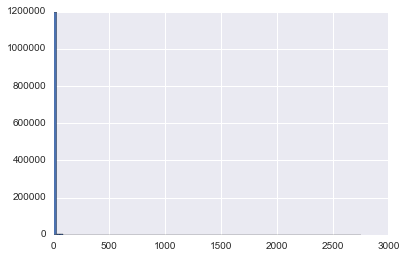

```python
df2['listing'].hist(bins = 100);

# This is useless!!
```

### 2-d. Basic statistics of the active users (8.07% of total sellers)

- distributions of the sellers by using 'sale' or 'listing'

```python
# dfa: active user data
dfa.head()
```

|  | id | time_on_site | positive_rating | neutral_rating | negative_rating | listing | listing_gmv | sale | buyers | gmv | listing_per_day |
| --- | --- | --- | --- | --- | --- | --- | --- | --- | --- | --- | --- |
| 2 | 100002348 | 76 | 1 | 0 | 0 | 1 | 10.0 | 1 | 1 | 10.0 | 0.013158 |
| 3 | 100002548 | 5 | 0 | 0 | 0 | 40 | 357.0 | 0 | 0 | 0.0 | 8.000000 |
| 25 | 100022372 | 26 | 0 | 0 | 0 | 9 | 250.0 | 0 | 0 | 0.0 | 0.346154 |
| 27 | 100023493 | 2 | 0 | 0 | 0 | 2 | 50.0 | 0 | 0 | 0.0 | 1.000000 |
| 42 | 100033232 | 57 | 0 | 0 | 0 | 9 | 143.0 | 1 | 1 | 25.0 | 0.157895 |

### 2-e. Feature selection

- drop unused feature

```python
## dff : data frame final - datasets after feature selection

dff = dfa.iloc[:,[2,3,4,6,7,8,9,10]]
```

```python
dff.head()
```

|  | positive_rating | neutral_rating | negative_rating | listing_gmv | sale | buyers | gmv | listing_per_day |
| --- | --- | --- | --- | --- | --- | --- | --- | --- |
| 2 | 1 | 0 | 0 | 10.0 | 1 | 1 | 10.0 | 0.013158 |
| 3 | 0 | 0 | 0 | 357.0 | 0 | 0 | 0.0 | 8.000000 |
| 25 | 0 | 0 | 0 | 250.0 | 0 | 0 | 0.0 | 0.346154 |
| 27 | 0 | 0 | 0 | 50.0 | 0 | 0 | 0.0 | 1.000000 |
| 42 | 0 | 0 | 0 | 143.0 | 1 | 1 | 25.0 | 0.157895 |

```python
dff['listing_per_day'].describe()
# mean is less than 0.5 while maximum is ~89 -> very skewed dataset?
```

```
count    97423.000000
mean         0.468860
std          1.504483
min          0.000000
25%          0.037037
50%          0.111111
75%          0.375000
max         89.111111
Name: listing_per_day, dtype: float64
```

```python
dtemp = dfa.listing
dtemp2 = dfa.listing[dfa.listing < 100]
```

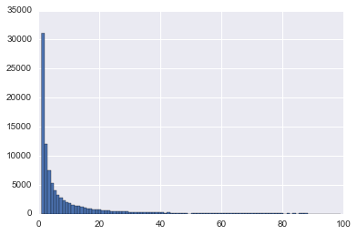

```python
dfa['listing'][dfa['listing']<100].hist(bins = 100);
```

### Most of the sellers are the ones with number of selling items less than 20 or maybe 5. This is very skewed data. The revenue distribution, however, could be different from the number of listing.

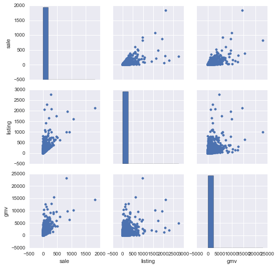

```python
g = sns.PairGrid(dfa[['sale','listing','gmv']])
g.map_diag(plt.hist)
g.map_offdiag(plt.scatter);
```

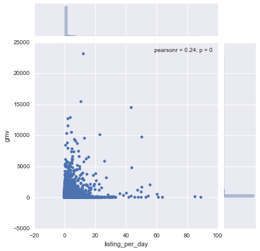

```python
sns.jointplot(dff.listing_per_day,dff.gmv);
```

#### When the revenue is compared with daily listing, clear correlation is hard to be seen.

# 3. Dimensional Reduction

#### Original 11 features were reduced to 8 by feature selection, and

```python
dff.head()
```

|  | positive_rating | neutral_rating | negative_rating | listing_gmv | sale | buyers | gmv | listing_per_day |
| --- | --- | --- | --- | --- | --- | --- | --- | --- |
| 2 | 1 | 0 | 0 | 10.0 | 1 | 1 | 10.0 | 0.013158 |
| 3 | 0 | 0 | 0 | 357.0 | 0 | 0 | 0.0 | 8.000000 |
| 25 | 0 | 0 | 0 | 250.0 | 0 | 0 | 0.0 | 0.346154 |
| 27 | 0 | 0 | 0 | 50.0 | 0 | 0 | 0.0 | 1.000000 |
| 42 | 0 | 0 | 0 | 143.0 | 1 | 1 | 25.0 | 0.157895 |

## 3-a. feature scaling

- Normalize each column before applying principal component analysis

```python
from sklearn.preprocessing import MinMaxScaler
```

```python
dff.describe()
```

|  | positive_rating | neutral_rating | negative_rating | listing_gmv | sale | buyers | gmv | listing_per_day |
| --- | --- | --- | --- | --- | --- | --- | --- | --- |
| count | 97423.000000 | 97423.000000 | 97423.000000 | 97423.000000 | 97423.000000 | 97423.000000 | 97423.000000 | 97423.000000 |
| mean | 2.387578 | 0.164581 | 0.036449 | 379.208462 | 2.699937 | 2.576353 | 67.179198 | 0.468860 |
| std | 11.463812 | 1.150350 | 0.366551 | 942.643014 | 13.607197 | 12.469444 | 278.430278 | 1.504483 |
| min | 0.000000 | 0.000000 | 0.000000 | 3.000000 | 0.000000 | 0.000000 | 0.000000 | 0.000000 |
| 25% | 0.000000 | 0.000000 | 0.000000 | 50.000000 | 0.000000 | 0.000000 | 0.000000 | 0.037037 |
| 50% | 0.000000 | 0.000000 | 0.000000 | 149.000000 | 0.000000 | 0.000000 | 0.000000 | 0.111111 |
| 75% | 1.000000 | 0.000000 | 0.000000 | 375.000000 | 2.000000 | 2.000000 | 42.000000 | 0.375000 |
| max | 1430.000000 | 164.000000 | 57.000000 | 57706.000000 | 1826.000000 | 1595.000000 | 23175.000000 | 89.111111 |

```python
scaler = MinMaxScaler()

# scaled data
dfs = pd.DataFrame(scaler.fit_transform(dff), columns = dff.columns)

# all columns are now 'scaled'
dfs.head()
```

|  | positive_rating | neutral_rating | negative_rating | listing_gmv | sale | buyers | gmv | listing_per_day |
| --- | --- | --- | --- | --- | --- | --- | --- | --- |
| 0 | 0.000699 | 0.0 | 0.0 | 0.000121 | 0.000548 | 0.000627 | 0.000431 | 0.000148 |
| 1 | 0.000000 | 0.0 | 0.0 | 0.006135 | 0.000000 | 0.000000 | 0.000000 | 0.089776 |
| 2 | 0.000000 | 0.0 | 0.0 | 0.004281 | 0.000000 | 0.000000 | 0.000000 | 0.003885 |
| 3 | 0.000000 | 0.0 | 0.0 | 0.000815 | 0.000000 | 0.000000 | 0.000000 | 0.011222 |
| 4 | 0.000000 | 0.0 | 0.0 | 0.002426 | 0.000548 | 0.000627 | 0.001079 | 0.001772 |

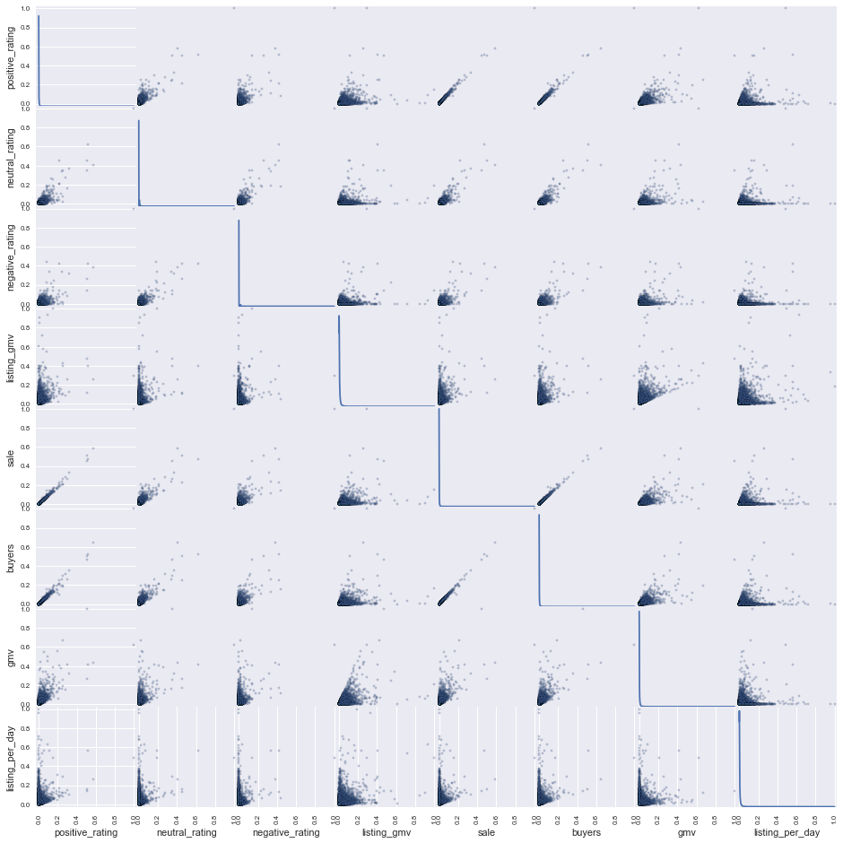

```python
pd.scatter_matrix(dfs, alpha = 0.3, figsize = (16,16), diagonal = 'kde');
```

- all values range between 0 and 1
- some positive correlation, but some not so clear

## 3-b. PCA

### include all features and let PCA handles the rest

```python
from sklearn.decomposition import PCA
pca_all = PCA().fit(dfs)  # including columns ['listing_gmv' ~ 'listing_per_day']
print pca_all.explained_variance_ratio_
```

```
[  5.67652802e-01   2.14000204e-01   1.44869071e-01   4.58475152e-02
   1.81139443e-02   9.07716579e-03   3.57220851e-04   8.20768457e-05]
```

```python
dfs.head()
```

|  | positive_rating | neutral_rating | negative_rating | listing_gmv | sale | buyers | gmv | listing_per_day |
| --- | --- | --- | --- | --- | --- | --- | --- | --- |
| 0 | 0.000699 | 0.0 | 0.0 | 0.000121 | 0.000548 | 0.000627 | 0.000431 | 0.000148 |
| 1 | 0.000000 | 0.0 | 0.0 | 0.006135 | 0.000000 | 0.000000 | 0.000000 | 0.089776 |
| 2 | 0.000000 | 0.0 | 0.0 | 0.004281 | 0.000000 | 0.000000 | 0.000000 | 0.003885 |
| 3 | 0.000000 | 0.0 | 0.0 | 0.000815 | 0.000000 | 0.000000 | 0.000000 | 0.011222 |
| 4 | 0.000000 | 0.0 | 0.0 | 0.002426 | 0.000548 | 0.000627 | 0.001079 | 0.001772 |

## Testing PCA with same number of original features (8 features)

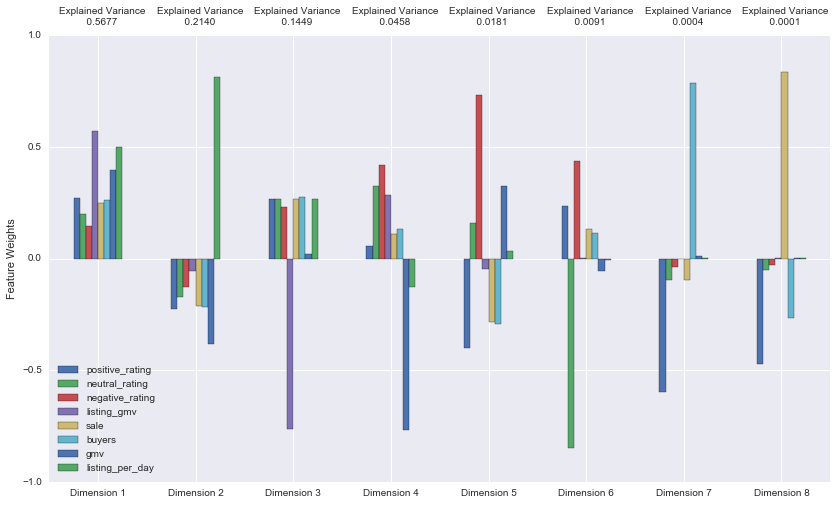

```python
pca8 = PCA(n_components=8)
pca8.fit(dfs)  # dfs: scaled dff

reduced8 = pca8.transform(dfs)  # df_reduced: change variable names

#dfr8.shape
pca8_results = rs.pca_results(dfs,pca8)
```

#### script for 'explained variance' plot courtesy of Udacity support team

> NOTE: A positive increase in a specific dimension corresponds with an increase of the positive-weighted features and a decrease of the negative-weighted features. The rate of increase or decrease is based on the indivdual feature weights.

## Must select first FIVE dimension to maintain 99% of all variances in data

```python
pca5 = PCA(n_components=5).fit(dfs)
reduced5 = pca5.transform(dfs)  # df_reduced: change variable names

reduced5.shape
```

```
(97423L, 5L)
```

# 4. Clustering Analysis

## 4-a. Assumption

#### I previously assumed that the sellers with no listing were categorized as 'new seller,' therefore the remaining 'active' sellers will need to be segmented into THREE groups.

1. Casual seller
2. Business seller
3. Top seller

#### After PCA, clustering analysis does not label the data, but rather segregates into group (in this case, three) purely based on the data; it's up to a human modeler to label them later, meaningfully.

## 4-b. Clustering

### 4-b-1. K-means clustering

### with sample_size = 20000

```python
from sklearn.cluster import KMeans
from sklearn.metrics import silhouette_samples, silhouette_score
import matplotlib.pyplot as plt
import matplotlib.cm as cm
import time

input_data = reduced5
```

```python
row_selections = np.random.randint(len(input_data),size=20000)

for n in range(2,6):
    startT = time.time()

    # Clustering is being done with entire datasets, but silhouette score computation is NOT.

    clusterer = KMeans(init = 'k-means++', n_clusters=n, n_init=10, max_iter = 500,
                       random_state= 200)

    clusterer.fit(reduced5)
    cluster_labels = clusterer.fit_predict(input_data)


    startT = time.time()
    silhouette_avg = silhouette_score(input_data[row_selections,:],
                                  cluster_labels[row_selections])
    sample_silhouette_values = silhouette_samples(input_data[row_selections,:],
                                              cluster_labels[row_selections])
    endT = time.time()
    print 'numer of clustering is',n,': silhouette score is',silhouette_avg
    print "elapsed time %.2f" % (endT-startT)
```

```
numer of clustering is 2 : silhouette score is 0.895474368978
elapsed time 114.40
numer of clustering is 3 : silhouette score is 0.851316633341
elapsed time 117.89
numer of clustering is 4 : silhouette score is 0.833795162921
elapsed time 121.22
numer of clustering is 5 : silhouette score is 0.759716759741
elapsed time 124.02
```

## TESTING plot when n = 3

```python
input_data = reduced5
row_selections = np.random.randint(len(input_data),size=30000)

# number of clusters
n = 3

startT = time.time()

clusterer = KMeans(init = 'k-means++', n_clusters=n, n_init=10, max_iter = 500)

clusterer.fit(reduced5)
#cluster_labels = clusterer.fit_predict(input_data)
cluster_labels = clusterer.labels_
```

```python
silhouette_avg = silhouette_score(input_data[row_selections,:],
                              cluster_labels[row_selections])
sample_silhouette_values = silhouette_samples(input_data[row_selections,:],
                                          cluster_labels[row_selections])
endT = time.time()
print 'numer of clustering is',n,': silhouette score is',silhouette_avg
print "elapsed time %.2f" % (endT-startT)
```

```
numer of clustering is 3 : silhouette score is 0.856348139089
elapsed time 234.08
```

> below can be skipped

```python
input_data = reduced5
row_selections = np.random.randint(len(input_data),size=40000)

# number of clusters
n = 3

clusterer = KMeans(init = 'k-means++', n_clusters=n, n_init=10, max_iter = 500,
                   random_state= 200)

clusterer.fit(reduced5)
cluster_labels = clusterer.fit_predict(input_data)

startT = time.time()
silhouette_avg = silhouette_score(input_data[row_selections,:],
                              cluster_labels[row_selections])
sample_silhouette_values = silhouette_samples(input_data[row_selections,:],
                                          cluster_labels[row_selections])
endT = time.time()
print 'numer of clustering is',n,': silhouette score is',silhouette_avg
print "elapsed time %.2f" % (endT-startT)
```

```
numer of clustering is 3 : silhouette score is 0.856467374834
elapsed time 2795.36
```

## Visualizing silhouette scores

```
29004
22
974
```

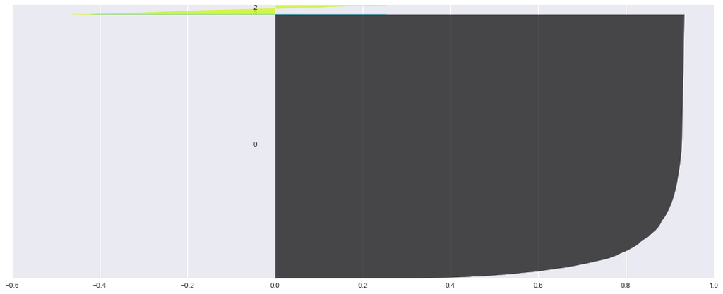

```python
y_lower = 10
nn_cluster = 3

#fig, (ax1,ax2) = plt.subplots(1,2)
fig, ax1 = plt.subplots(1,1)
fig.set_size_inches(18,7)

# for i in range(1,nn_cluster):
for i in range(0,nn_cluster):
    ith_cluster_silhouette_values = sample_silhouette_values[cluster_labels[row_selections] == i]
    ith_cluster_silhouette_values.sort()

    size_cluster_i = ith_cluster_silhouette_values.shape[0]
    y_upper = y_lower + size_cluster_i
    color = cm.spectral(float(i)/nn_cluster)
    ax1.fill_betweenx(np.arange(y_lower,y_upper), 0,
                     ith_cluster_silhouette_values,
                     facecolor = color, edgecolor = color, alpha = 0.7)
    ax1.text(-0.05, y_lower + 0.5*size_cluster_i, str(i))
    y_lower = y_upper + 10
    ax1.set_yticks([])
    print size_cluster_i
```

Append the cluster groups to the database and examine each clusters

```python
# dfs : scaled data
dfs['clusters'] = cluster_labels

# dfa: original 'active' data
dfa['clusters'] = cluster_labels
```

```python
dfa[dfa['clusters'] == 1].head()
```

|  | id | time_on_site | positive_rating | neutral_rating | negative_rating | listing | listing_gmv | sale | buyers | gmv | listing_per_day | clusters |
| --- | --- | --- | --- | --- | --- | --- | --- | --- | --- | --- | --- | --- |
| 3 | 100002548 | 5 | 0 | 0 | 0 | 40 | 357.0 | 0 | 0 | 0.0 | 8.000000 | 1 |
| 160 | 100132264 | 65 | 19 | 1 | 0 | 93 | 2065.0 | 21 | 20 | 490.0 | 1.430769 | 1 |
| 242 | 100203484 | 79 | 27 | 1 | 0 | 105 | 2477.0 | 29 | 29 | 754.0 | 1.329114 | 1 |
| 1232 | 100921416 | 60 | 22 | 2 | 0 | 108 | 1728.0 | 27 | 27 | 408.0 | 1.800000 | 1 |
| 1242 | 100924949 | 66 | 34 | 3 | 0 | 478 | 3958.0 | 38 | 38 | 398.0 | 7.242424 | 1 |

```python
dfa[dfa['clusters'] == 2].head()
```

|  | id | time_on_site | positive_rating | neutral_rating | negative_rating | listing | listing_gmv | sale | buyers | gmv | listing_per_day | clusters |
| --- | --- | --- | --- | --- | --- | --- | --- | --- | --- | --- | --- | --- |
| 4558 | 103409199 | 65 | 162 | 7 | 1 | 249 | 8466.0 | 174 | 155 | 5553.0 | 3.830769 | 2 |
| 23665 | 117759762 | 69 | 79 | 6 | 0 | 145 | 20190.0 | 85 | 76 | 12650.0 | 2.101449 | 2 |
| 27055 | 120319354 | 78 | 186 | 10 | 5 | 515 | 11171.0 | 209 | 199 | 4443.0 | 6.602564 | 2 |
| 33949 | 125512323 | 63 | 209 | 6 | 1 | 334 | 8935.0 | 220 | 183 | 4773.0 | 5.301587 | 2 |
| 53650 | 140306250 | 48 | 210 | 18 | 10 | 985 | 8789.0 | 294 | 273 | 2733.0 | 20.520833 | 2 |

```python
dfa[dfa['clusters'] == 0].tail()
```

|  | id | time_on_site | positive_rating | neutral_rating | negative_rating | listing | listing_gmv | sale | buyers | gmv | listing_per_day | clusters |
| --- | --- | --- | --- | --- | --- | --- | --- | --- | --- | --- | --- | --- |
| 1207710 | 999942243 | 6 | 0 | 0 | 0 | 1 | 90.0 | 0 | 0 | 0.0 | 0.166667 | 0 |
| 1207735 | 999963328 | 20 | 3 | 1 | 0 | 12 | 205.0 | 4 | 4 | 18.0 | 0.600000 | 0 |
| 1207748 | 999974669 | 5 | 0 | 0 | 0 | 1 | 10.0 | 0 | 0 | 0.0 | 0.200000 | 0 |
| 1207751 | 999976784 | 8 | 1 | 0 | 0 | 9 | 655.0 | 1 | 1 | 80.0 | 1.125000 | 0 |
| 1207756 | 999981906 | 28 | 0 | 0 | 0 | 3 | 416.0 | 0 | 0 | 0.0 | 0.107143 | 0 |

```python
# df2: original import without install_date column
# del df_clustered
df_clustered = pd.merge(df2, dfa[['id','clusters']],on='id',how='left')
df_clustered2 = df_clustered.fillna(3)
```

```python
df_clustered2.head()
```

|  | id | time_on_site | positive_rating | neutral_rating | negative_rating | listing | listing_gmv | sale | buyers | gmv | listing_per_day | clusters |
| --- | --- | --- | --- | --- | --- | --- | --- | --- | --- | --- | --- | --- |
| 0 | 100000126 | 27 | 0 | 0 | 0 | 0 | 0.0 | 0 | 0 | 0.0 | 0.000000 | 3.0 |
| 1 | 100000329 | 5 | 0 | 0 | 0 | 0 | 0.0 | 0 | 0 | 0.0 | 0.000000 | 3.0 |
| 2 | 100002348 | 76 | 1 | 0 | 0 | 1 | 10.0 | 1 | 1 | 10.0 | 0.013158 | 0.0 |
| 3 | 100002548 | 5 | 0 | 0 | 0 | 40 | 357.0 | 0 | 0 | 0.0 | 8.000000 | 1.0 |
| 4 | 100003707 | 23 | 0 | 0 | 0 | 0 | 0.0 | 0 | 0 | 0.0 | 0.000000 | 3.0 |

```python
df_kmeans = df_clustered2.groupby(df_clustered2['clusters'])
```

```python
df_kmeans[['listing','listing_gmv','sale','buyers','gmv']].describe()
```

| clusters |  | listing | listing_gmv | sale | buyers | gmv |
| --- | --- | --- | --- | --- | --- | --- |
| 0.0 | count | 9.413400e+04 | 9.413400e+04 | 9.413400e+04 | 9.413400e+04 | 9.413400e+04 |
|  | mean | 8.857225e+00 | 2.766327e+02 | 1.640852e+00 | 1.591922e+00 | 4.214862e+01 |
|  | std | 1.459221e+01 | 3.826602e+02 | 3.958972e+00 | 3.793329e+00 | 1.017466e+02 |
|  | min | 1.000000e+00 | 3.000000e+00 | 0.000000e+00 | 0.000000e+00 | 0.000000e+00 |
|  | 25% | 1.000000e+00 | 5.000000e+01 | 0.000000e+00 | 0.000000e+00 | 0.000000e+00 |
|  | 50% | 3.000000e+00 | 1.390000e+02 | 0.000000e+00 | 0.000000e+00 | 0.000000e+00 |
|  | 75% | 1.000000e+01 | 3.400000e+02 | 1.000000e+00 | 1.000000e+00 | 3.500000e+01 |
|  | max | 2.250000e+02 | 4.000000e+03 | 6.300000e+01 | 5.800000e+01 | 1.675000e+03 |
| 1.0 | count | 3.217000e+03 | 3.217000e+03 | 3.217000e+03 | 3.217000e+03 | 3.217000e+03 |
|  | mean | 1.076416e+02 | 3.035773e+03 | 2.751601e+01 | 2.581442e+01 | 6.769459e+02 |
|  | std | 9.237751e+01 | 2.582239e+03 | 3.271505e+01 | 3.037759e+01 | 7.853030e+02 |
|  | min | 3.000000e+00 | 5.000000e+01 | 0.000000e+00 | 0.000000e+00 | 0.000000e+00 |
|  | 25% | 4.500000e+01 | 1.425000e+03 | 4.000000e+00 | 4.000000e+00 | 1.050000e+02 |
|  | 50% | 8.600000e+01 | 2.414000e+03 | 1.700000e+01 | 1.600000e+01 | 4.590000e+02 |
|  | 75% | 1.400000e+02 | 3.864000e+03 | 4.000000e+01 | 3.700000e+01 | 9.500000e+02 |
|  | max | 7.690000e+02 | 2.309300e+04 | 2.550000e+02 | 2.480000e+02 | 8.446000e+03 |
| 2.0 | count | 7.200000e+01 | 7.200000e+01 | 7.200000e+01 | 7.200000e+01 | 7.200000e+01 |
|  | mean | 7.049444e+02 | 1.579164e+04 | 2.785694e+02 | 2.513472e+02 | 5.547861e+03 |
|  | std | 5.952987e+02 | 1.218514e+04 | 2.797039e+02 | 2.529081e+02 | 4.071271e+03 |
|  | min | 3.900000e+01 | 1.547000e+03 | 0.000000e+00 | 0.000000e+00 | 0.000000e+00 |
|  | 25% | 3.087500e+02 | 7.944750e+03 | 1.240000e+02 | 1.182500e+02 | 2.717750e+03 |
|  | 50% | 5.790000e+02 | 1.208950e+04 | 2.295000e+02 | 1.975000e+02 | 4.688500e+03 |
|  | 75% | 8.635000e+02 | 2.045775e+04 | 3.197500e+02 | 3.042500e+02 | 7.353250e+03 |
|  | max | 2.758000e+03 | 5.770600e+04 | 1.826000e+03 | 1.595000e+03 | 2.317500e+04 |
| 3.0 | count | 1.110351e+06 | 1.110351e+06 | 1.110351e+06 | 1.110351e+06 | 1.110351e+06 |
|  | mean | 0.000000e+00 | 0.000000e+00 | 0.000000e+00 | 0.000000e+00 | 0.000000e+00 |
|  | std | 0.000000e+00 | 0.000000e+00 | 0.000000e+00 | 0.000000e+00 | 0.000000e+00 |
|  | min | 0.000000e+00 | 0.000000e+00 | 0.000000e+00 | 0.000000e+00 | 0.000000e+00 |
|  | 25% | 0.000000e+00 | 0.000000e+00 | 0.000000e+00 | 0.000000e+00 | 0.000000e+00 |
|  | 50% | 0.000000e+00 | 0.000000e+00 | 0.000000e+00 | 0.000000e+00 | 0.000000e+00 |
|  | 75% | 0.000000e+00 | 0.000000e+00 | 0.000000e+00 | 0.000000e+00 | 0.000000e+00 |
|  | max | 0.000000e+00 | 0.000000e+00 | 0.000000e+00 | 0.000000e+00 | 0.000000e+00 |

### 4-b-2. DBSCAN clustering

As seen in the figure and number of users in each clusters, clusters are not evenly distributed and one or two clusters contain most of the datasets.

#### DBSCAN is known to be good for data which contains clusters of similar density.

NOTE: There are two parameters to the algorithm, `min_samples` and `eps`, which define formally what we mean when we say dense. Higher `min_samples` or lower `eps` indicate higher density necessary to form a cluster.

# DBSCAN crashes when processed with all of the data!!!

random data sampling was used before being processed

```python
startT = time.time()
from sklearn.cluster import DBSCAN

row_selections = np.random.randint(len(input_data),size=40000)
db = DBSCAN(eps=0.5, min_samples = 30).fit(input_data[row_selections,:])
# db = DBSCAN(eps=0.5, min_samples = 30).fit(input_data)

endT = time.time()
print "elapsed time %.2f minutes" % ((endT-startT)/60.0)
```

```
elapsed time 3.27 minutes
```

```python
startT = time.time()
from sklearn.cluster import DBSCAN

row_selections = np.random.randint(len(input_data),size=60000)
db = DBSCAN(eps=0.5, min_samples = 30).fit(input_data[row_selections,:])
# db = DBSCAN(eps=0.5, min_samples = 30).fit(input_data)

endT = time.time()
print "elapsed time %.2f minutes" % ((endT-startT)/60.0)
```

```
elapsed time 13.87 minutes
```

```python
labels = db.labels_
n_clusters_ = len(set(labels)) - (1 if -1 in labels else 0)
```

```python
n_clusters_
```

```
1
```

```python
len(db.labels_[db.labels_==0])
```

```
59998
```

```python
len(db.labels_[db.labels_==-1])
```

```
2
```

> DBSCAN does not work well with the entire dataset  
> Maybe the data doesn't have much variability in density

### 4-b-3. Hierarchical clustering

```python
input_data.shape
```

```
(97423, 5)
```

```python
from sklearn.cluster import AgglomerativeClustering
```

```python
startT = time.time()
row_selections = np.random.randint(len(input_data),size=20000)
model = AgglomerativeClustering(linkage = 'average',n_clusters = 3)
model.fit(input_data[row_selections,:])
endT = time.time()

print "elapsed time %.2f" % (endT-startT)
```

```
elapsed time 3503.71
```

```python
set(model.labels_)
```

```
{0, 1, 2}
```

```python
startT = time.time()
row_selections = np.random.randint(len(input_data),size=30000)
model = AgglomerativeClustering(linkage = 'average',n_clusters = 3)
model.fit(input_data[row_selections,:])
endT = time.time()

print "elapsed time %.2f" % (endT-startT)
```

```
elapsed time 11407.37
```

```python
set(model.labels_)
```

```
{0, 1, 2}
```

#### silhouette score for Agg clustering

```python
# number of clusters
n = 3

startT = time.time()

#clusterer = KMeans(init = 'k-means++', n_clusters=n, n_init=10, max_iter = 500)

#clusterer.fit(reduced5)
#cluster_labels = clusterer.fit_predict(input_data)
#cluster_labels = clusterer.labels_
cluster_labels = model.labels_

silhouette_avg = silhouette_score(input_data[row_selections,:],
                              cluster_labels)
sample_silhouette_values = silhouette_samples(input_data[row_selections,:],
                                          cluster_labels)
endT = time.time()
print 'numer of clustering is',n,': silhouette score is',silhouette_avg
print "elapsed time %.2f" % (endT-startT)
```

```
numer of clustering is 3 : silhouette score is 0.987138129943
elapsed time 836.37
```

```
29998
1
1
```

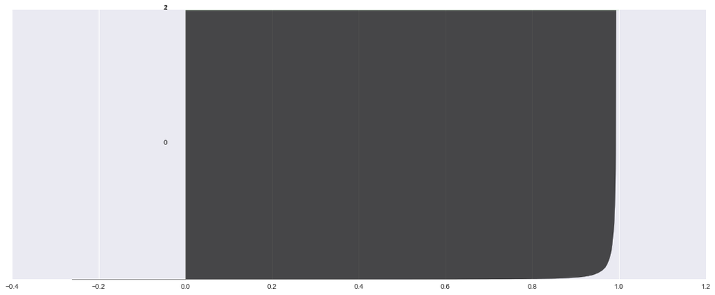

```python
y_lower = 10
nn_cluster = 3

#fig, (ax1,ax2) = plt.subplots(1,2)
fig, ax1 = plt.subplots(1,1)
fig.set_size_inches(18,7)

# for i in range(1,nn_cluster):
for i in range(0,nn_cluster):
    ith_cluster_silhouette_values = sample_silhouette_values[cluster_labels == i]
    ith_cluster_silhouette_values.sort()

    size_cluster_i = ith_cluster_silhouette_values.shape[0]
    y_upper = y_lower + size_cluster_i
    color = cm.spectral(float(i)/nn_cluster)
    ax1.fill_betweenx(np.arange(y_lower,y_upper), 0,
                     ith_cluster_silhouette_values,
                     facecolor = color, edgecolor = color, alpha = 0.7)
    ax1.text(-0.05, y_lower + 0.5*size_cluster_i, str(i))
    y_lower = y_upper + 10
    ax1.set_yticks([])
    print size_cluster_i
```

> AgglomerativeClustering takes long time!!

## 4-c. Data Labeling with group numbers

### Labeling based on average listings per each group

```python
group_listing = df_clustered2['listing'].groupby(df_clustered2['clusters'])
group_listing.mean()
```

```
clusters
0.0      8.857225
1.0    107.641592
2.0    704.944444
3.0      0.000000
Name: listing, dtype: float64
```

## 3-4. Export to csv file

```python
df_clustered2.to_csv('All_data_clustered.csv')
df_clustered2[df_clustered2['clusters']==0].to_csv('data_casual_seller.csv')
df_clustered2[df_clustered2['clusters']==1].to_csv('data_business_seller.csv')
df_clustered2[df_clustered2['clusters']==2].to_csv('data_top_seller.csv')
df_clustered2[df_clustered2['clusters']==3].to_csv('data_new_seller.csv')
```

# Future recommendation

- Now the clustering the seller is done.
- Based on the seller segregation done in the previous step, we may be able to predict which group a unknown seller belongs when features of the seller are known.